# Activity: Scraping Nuclear Reactors

Matt Beckman

October 25, 2017

*Source file* ⇒ ScrapingNuclearReactors.Rmd

# Grading

Assignment is worth a total of 10 points.

- [2 points] Turn in HTML with embedded .Rmd file (e.g. “DataComputing simple” template)
- [2 points] Successfully scrape raw data for Japan Reactors from Wikipedia
- [2 points] Your Turn #1: Tidy Data & Data Cleaning (Japan)
- [2 points] Your Turn #2: Plot Net Generation Capacity vs Construction Date
- [SKIP] Your Turn #3: Scrape & Clean China Data (then Merge with Japan)
- [SKIP] Your Turn #4: Scrape USA Reactors
- [2 points] Your Turn #5: Reconstruct Info Graphic of Japan Reactors (or other country of interest)

Assignment Sections & Hints:

- Scrape Japan Data from Wikipedia
  - Hint: if you’re having trouble with “subscript out of bounds”, just get the xpath for the Japan table directly, rather than reading all tables at once
- Your Turn #1: Tidy Data & Data Cleaning
- Your Turn #2: Plot Net Generation Capacity vs Construction Date
- [**SKIP**] Your Turn #3: Scrape & Clean China Data (then Merge with Japan)
  - Hint: use `mutate()` to create the new variable “country”
  - Hint: use either `cbind()` or `rbind()` to combine the data tables together (be careful to match column order)
- [**SKIP**] Your Turn #4: Scrape USA Reactors
- Your Turn #5: Reconstruct Info Graphic of Japan Reactors
  - Hint: use `paste()` function to combine the `name` and `reactor` variables to create an informative unique case ID

# Activity

### Set-Up

```r
library(rvest)
library(lubridate)
```

### Nuclear Reactor Data

The Nuclear Reactor Data are scraped from Wikipedia: https://en.wikipedia.org/wiki/List_of_nuclear_reactors

### Locate & Inspect Japan Reactor Data

```r
page <- "https://en.wikipedia.org/wiki/List_of_nuclear_reactors"
XPATH <- '//*[@id="mw-content-text"]/div/table'  # Scrape all tables
# XPATH <- '//*[@id="mw-content-text"]/div/table[25]'  # Scrape Japan only

table_list <-
  page %>%
  read_html() %>%
  html_nodes(xpath = XPATH) %>%
  html_table(fill = TRUE)

# extract the data table from the "list"
#   This step is needed even if the list only has one data table in it (i.e. if you scraped Japan only)
Japan <- table_list[[25]]  # The Japan table is element 25 in the `table_list` object

# Inspect data table
str(Japan)
```

```
## 'data.frame':    64 obs. of  10 variables:
##  $ Name                     : chr  "Name" "Fukushima Daiichi" "Fukushima Daiichi" "Fukushima Daiichi" ...
##  $ Unit
## No.                : chr  "Unit\nNo." "1" "2" "3" ...
##  $ Reactor                  : chr  "Type" "BWR" "BWR" "BWR" ...
##  $ Reactor                  : chr  "Reactor" "BWR-3" "BWR-4" "BWR-4" ...
##  $ Status                   : chr  "Model" "Inoperable" "Inoperable" "Inoperable" ...
##  $ Capacity in MW           : chr  "Capacity in MW" "439" "760" "760" ...
##  $ Capacity in MW           : chr  "Capacity in MW" "460" "784" "784" ...
##  $ Construction Start Date  : chr  "Construction Start Date" "25 July 1967" "9 June 1969" "28 December 1970" ...
##  $ Commercial Operation Date: chr  "Net" "26 March 1971" "18 July 1974" "27 March 1976" ...
##  $ Closure                  : chr  "Gross" "19 May 2011" "19 May 2011" "19 May 2011" ...
```

```r
head(Japan)
```

```
##                Name Unit\nNo. Reactor Reactor                Status
## 1              Name Unit\nNo.    Type Reactor                 Model
## 2 Fukushima Daiichi         1     BWR   BWR-3            Inoperable
## 3 Fukushima Daiichi         2     BWR   BWR-4            Inoperable
## 4 Fukushima Daiichi         3     BWR   BWR-4            Inoperable
## 5 Fukushima Daiichi         4     BWR   BWR-4 Shut down/ Inoperable
## 6 Fukushima Daiichi         5     BWR   BWR-4             Shut down
##   Capacity in MW Capacity in MW Construction Start Date
## 1 Capacity in MW Capacity in MW Construction Start Date
## 2            439            460            25 July 1967
## 3            760            784             9 June 1969
## 4            760            784        28 December 1970
## 5            760            784        12 February 1973
## 6            760            784             22 May 1972
##   Commercial Operation Date          Closure
## 1                       Net            Gross
## 2             26 March 1971      19 May 2011
## 3              18 July 1974      19 May 2011
## 4             27 March 1976      19 May 2011
## 5           12 October 1978      19 May 2011
## 6             18 April 1978 17 December 2013
```

### Your Turn: Data Cleaning

In what ways is the data table tidy?

- each column is a variable
- rows are mostly cases (not quite tidy, but close)

In what ways is the data table NOT tidy?

- first row is a continuation of variable names (not a case)
- DataComputing text alleges missing columns, but I didn’t have that issue…

##### Cleaning Up Variable Names

```r
# create unique names for variables 4 & 7
names(Japan)[c(4, 7)] <- c("model", "grossMW")

# Inspect result
head(Japan)
```

```
##                Name Unit\nNo. Reactor   model                Status
## 1              Name Unit\nNo.    Type Reactor                 Model
## 2 Fukushima Daiichi         1     BWR   BWR-3            Inoperable
## 3 Fukushima Daiichi         2     BWR   BWR-4            Inoperable
## 4 Fukushima Daiichi         3     BWR   BWR-4            Inoperable
## 5 Fukushima Daiichi         4     BWR   BWR-4 Shut down/ Inoperable
## 6 Fukushima Daiichi         5     BWR   BWR-4             Shut down
##   Capacity in MW        grossMW Construction Start Date
## 1 Capacity in MW Capacity in MW Construction Start Date
## 2            439            460            25 July 1967
## 3            760            784             9 June 1969
## 4            760            784        28 December 1970
## 5            760            784        12 February 1973
## 6            760            784             22 May 1972
##   Commercial Operation Date          Closure
## 1                       Net            Gross
## 2             26 March 1971      19 May 2011
## 3              18 July 1974      19 May 2011
## 4             27 March 1976      19 May 2011
## 5           12 October 1978      19 May 2011
## 6             18 April 1978 17 December 2013
```

```r
# cleaning up the Japan Data
Japan <-
  Japan %>%
  filter(row_number() > 1) %>%      # drop the first row in the table (continuation of names)
  rename(name = Name, reactor = `Unit\nNo.`,    # Note the use of back-ticks: `
         type = Reactor, status = Status,
         netMW = `Capacity in MW`,
         construction = `Construction Start Date`,
         operation = `Commercial Operation Date`, closure = Closure)

head(Japan)
```

```
##                name reactor type model                status netMW grossMW
## 1 Fukushima Daiichi       1  BWR BWR-3            Inoperable   439     460
## 2 Fukushima Daiichi       2  BWR BWR-4            Inoperable   760     784
## 3 Fukushima Daiichi       3  BWR BWR-4            Inoperable   760     784
## 4 Fukushima Daiichi       4  BWR BWR-4 Shut down/ Inoperable   760     784
## 5 Fukushima Daiichi       5  BWR BWR-4             Shut down   760     784
## 6 Fukushima Daiichi       6  BWR BWR-5             Shut down  1067    1100
##       construction       operation          closure
## 1     25 July 1967   26 March 1971      19 May 2011
## 2      9 June 1969    18 July 1974      19 May 2011
## 3 28 December 1970   27 March 1976      19 May 2011
## 4 12 February 1973 12 October 1978      19 May 2011
## 5      22 May 1972   18 April 1978 17 December 2013
## 6  26 October 1973 24 October 1979 17 December 2013
```

##### Cleaning Up Variable Formats

From `str()` we can see that everything is treated as character strings (even numeric and date variables).

```r
str(Japan)
```

```
## 'data.frame':    63 obs. of  10 variables:
##  $ name        : chr  "Fukushima Daiichi" "Fukushima Daiichi" "Fukushima Daiichi" "Fukushima Daiichi" ...
##  $ reactor     : chr  "1" "2" "3" "4" ...
##  $ type        : chr  "BWR" "BWR" "BWR" "BWR" ...
##  $ model       : chr  "BWR-3" "BWR-4" "BWR-4" "BWR-4" ...
##  $ status      : chr  "Inoperable" "Inoperable" "Inoperable" "Shut down/ Inoperable" ...
##  $ netMW       : chr  "439" "760" "760" "760" ...
##  $ grossMW     : chr  "460" "784" "784" "784" ...
##  $ construction: chr  "25 July 1967" "9 June 1969" "28 December 1970" "12 February 1973" ...
##  $ operation   : chr  "26 March 1971" "18 July 1974" "27 March 1976" "12 October 1978" ...
##  $ closure     : chr  "19 May 2011" "19 May 2011" "19 May 2011" "19 May 2011" ...
```

Let’s convert each variable to the most appropriate type using `mutate()`. Notice the warning “Warning: 5 failed to parse”. Can you spot from the original data table which 5 values may have caused the warning and why R may have failed to reformat them? (Hint: look at the closure dates). It’s important to pay attention to warnings and understand where they come from!

```r
Japan <-
  Japan %>%
  mutate(netMW = as.numeric(netMW), grossMW = as.numeric(grossMW)) %>%
  mutate(construction = dmy(construction), operation = dmy(operation), closure = dmy(closure))
```

```
## Warning: 5 failed to parse.
```

```r
# Inspect Result
head(Japan)
```

```
##                name reactor type model                status netMW grossMW
## 1 Fukushima Daiichi       1  BWR BWR-3            Inoperable   439     460
## 2 Fukushima Daiichi       2  BWR BWR-4            Inoperable   760     784
## 3 Fukushima Daiichi       3  BWR BWR-4            Inoperable   760     784
## 4 Fukushima Daiichi       4  BWR BWR-4 Shut down/ Inoperable   760     784
## 5 Fukushima Daiichi       5  BWR BWR-4             Shut down   760     784
## 6 Fukushima Daiichi       6  BWR BWR-5             Shut down  1067    1100
##   construction  operation    closure
## 1   1967-07-25 1971-03-26 2011-05-19
## 2   1969-06-09 1974-07-18 2011-05-19
## 3   1970-12-28 1976-03-27 2011-05-19
## 4   1973-02-12 1978-10-12 2011-05-19
## 5   1972-05-22 1978-04-18 2013-12-17
## 6   1973-10-26 1979-10-24 2013-12-17
```

### Your Turn: Plot Net Generation Capacity vs Construction Date

This sounds like a job for `ggplot()`. Notice the warning again… do you see where that one comes from? Here are a few possible observations from the graph:

- most reactors are either type “PWR” or “BWR”
- there is a slight positive trend indicating that perhaps reactors constructed more recently have greater net generation capacity
- type “PWR” reactors may appear to be associated with slightly greater net generation capacity than “BWR” reactors constructed near the same time

```
## Warning: Removed 3 rows containing missing values (geom_point).
```

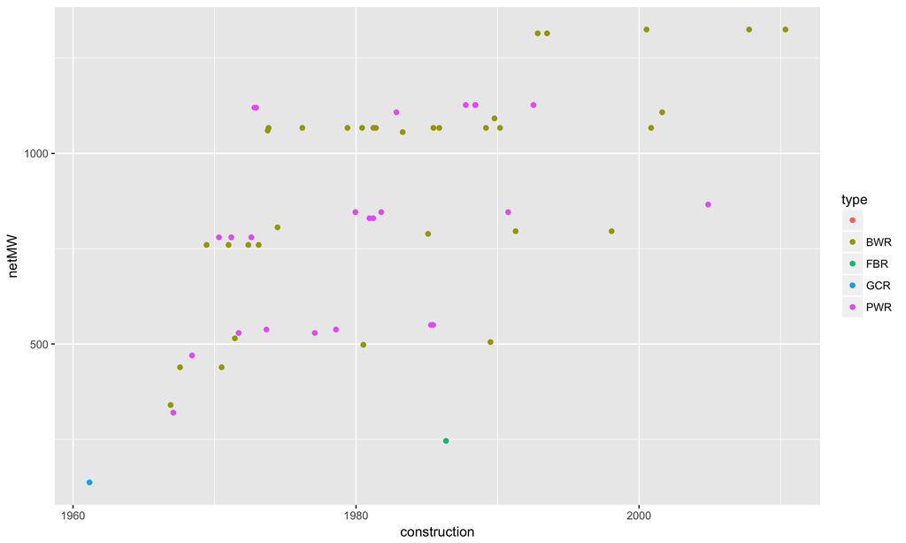

```r
Japan %>%
  ggplot(aes(y = netMW, x = construction)) +
  geom_point(aes(color = type))
```

### Your Turn: Scrape & Merge China Data

##### Scrape (& Clean)

Since you’re doing the same steps as before, you should use copy and paste liberally and just make small changes to adapt the code to the China data. No need to re-type the whole thing! You may get a few warnings again (at least I did), can you track down the problem cases in the original table?

```r
### You can directly scrape China (and only China) if you want...

# same webpage as before
page <- "https://en.wikipedia.org/wiki/List_of_nuclear_reactors"

# new xpath (we need the China table)
XPATH <- '//*[@id="mw-content-text"]/table[12]'

table_list <-
  page %>%
  read_html() %>%
  html_nodes(xpath = XPATH) %>%
  html_table(fill = TRUE)

# extract the data table from the "list" (even though the list only has one data table in it)
China <- table_list[[1]]

# Inspect data table
str(China)
head(China)
```

```r
# extract the China data table from the "list"
China <- table_list[[13]]

# Inspect data table
str(China)
```

```
## 'data.frame':    81 obs. of  10 variables:
##  $ Name                     : chr  "Name" "Changjiang I" "Changjiang I" "Changjiang II" ...
##  $ Unit
## No.                : chr  "Unit\nNo." "1" "2" "3" ...
##  $ Reactor                  : chr  "Type" "PWR" "PWR" "PWR" ...
##  $ Reactor                  : chr  "Reactor" "CNP-600" "CNP-600" "CNP-600" ...
##  $ Status                   : chr  "Model" "Operational" "Operational" "Planned" ...
##  $ Capacity in MW           : chr  "Capacity in MW" "610" "610" "610" ...
##  $ Capacity in MW           : chr  "Capacity in MW" "650" "650" "650" ...
##  $ Construction Start Date  : chr  "Construction Start Date" "25 April 2010" "21 November 2010" "" ...
##  $ Commercial Operation Date: chr  "Net" "25 December 2015" "20 June 2016" "" ...
##  $ Closure                  : chr  "Gross" "" "" "" ...
```

```r
head(China)
```

```
##                   Name Unit\nNo. Reactor Reactor      Status
## 1                 Name Unit\nNo.    Type Reactor       Model
## 2         Changjiang I         1     PWR CNP-600 Operational
## 3         Changjiang I         2     PWR CNP-600 Operational
## 4        Changjiang II         3     PWR CNP-600     Planned
## 5        Changjiang II         4     PWR CNP-600     Planned
## 6 Daya Bay (Guangdong)         1     PWR   M-310 Operational
##   Capacity in MW Capacity in MW Construction Start Date
## 1 Capacity in MW Capacity in MW Construction Start Date
## 2            610            650           25 April 2010
## 3            610            650        21 November 2010
## 4            610            650
## 5            610            650
## 6            944            984           7 August 1987
##   Commercial Operation Date Closure
## 1                       Net   Gross
## 2          25 December 2015
## 3              20 June 2016
## 4
## 5
## 6           1 February 1994
```

```r
# create unique names for variables 4 & 7
names(China)[c(4, 7)] <- c("model", "grossMW")

# cleaning up the China Data (almost identical to Japan cleaning)
China <-
  China %>%
  filter(row_number() > 1) %>%
  rename(name = Name, reactor = `Unit\nNo.`,  # again, backticks needed here because of "\n"
         type = Reactor, status = Status,
         netMW = `Capacity in MW`,            # backticks because of white space
         construction = `Construction Start Date`,
         operation = `Commercial Operation Date`, closure = Closure) %>%
  mutate(netMW = as.numeric(netMW), grossMW = as.numeric(grossMW)) %>%
  mutate(construction = dmy(construction), operation = dmy(operation))
head(China)
```

```
##                   name reactor type   model      status netMW grossMW
## 1         Changjiang I       1  PWR CNP-600 Operational   610     650
## 2         Changjiang I       2  PWR CNP-600 Operational   610     650
## 3        Changjiang II       3  PWR CNP-600     Planned   610     650
## 4        Changjiang II       4  PWR CNP-600     Planned   610     650
## 5 Daya Bay (Guangdong)       1  PWR   M-310 Operational   944     984
## 6 Daya Bay (Guangdong)       2  PWR   M-310 Operational   944     984
##   construction  operation closure
## 1   2010-04-25 2015-12-25
## 2   2010-11-21 2016-06-20
## 3         <NA>       <NA>
## 4         <NA>       <NA>
## 5   1987-08-07 1994-02-01
## 6   1988-04-07 1994-05-06
```

##### Merging China and Japan

```r
Japan <-
  Japan %>%
  mutate(country = "Japan")

China <-
  China %>%
  mutate(country = "China")

# Inspect the results
head(Japan)
```

```
##                name reactor type model                status netMW grossMW
## 1 Fukushima Daiichi       1  BWR BWR-3            Inoperable   439     460
## 2 Fukushima Daiichi       2  BWR BWR-4            Inoperable   760     784
## 3 Fukushima Daiichi       3  BWR BWR-4            Inoperable   760     784
## 4 Fukushima Daiichi       4  BWR BWR-4 Shut down/ Inoperable   760     784
## 5 Fukushima Daiichi       5  BWR BWR-4             Shut down   760     784
## 6 Fukushima Daiichi       6  BWR BWR-5             Shut down  1067    1100
##   construction  operation    closure country
## 1   1967-07-25 1971-03-26 2011-05-19   Japan
## 2   1969-06-09 1974-07-18 2011-05-19   Japan
## 3   1970-12-28 1976-03-27 2011-05-19   Japan
## 4   1973-02-12 1978-10-12 2011-05-19   Japan
## 5   1972-05-22 1978-04-18 2013-12-17   Japan
## 6   1973-10-26 1979-10-24 2013-12-17   Japan
```

```r
head(China)
```

```
##                   name reactor type   model      status netMW grossMW
## 1         Changjiang I       1  PWR CNP-600 Operational   610     650
## 2         Changjiang I       2  PWR CNP-600 Operational   610     650
## 3        Changjiang II       3  PWR CNP-600     Planned   610     650
## 4        Changjiang II       4  PWR CNP-600     Planned   610     650
## 5 Daya Bay (Guangdong)       1  PWR   M-310 Operational   944     984
## 6 Daya Bay (Guangdong)       2  PWR   M-310 Operational   944     984
##   construction  operation closure country
## 1   2010-04-25 2015-12-25           China
## 2   2010-11-21 2016-06-20           China
## 3         <NA>       <NA>           China
## 4         <NA>       <NA>           China
## 5   1987-08-07 1994-02-01           China
## 6   1988-04-07 1994-05-06           China
```

```r
# Combine them together
China_Japan <- rbind(China, Japan)

# Inspect Results
str(China_Japan)   # structure
```

```
## 'data.frame':    143 obs. of  11 variables:
##  $ name        : chr  "Changjiang I" "Changjiang I" "Changjiang II" "Changjiang II" ...
##  $ reactor     : chr  "1" "2" "3" "4" ...
##  $ type        : chr  "PWR" "PWR" "PWR" "PWR" ...
##  $ model       : chr  "CNP-600" "CNP-600" "CNP-600" "CNP-600" ...
##  $ status      : chr  "Operational" "Operational" "Planned" "Planned" ...
##  $ netMW       : num  610 610 610 610 944 944 1000 1000 1080 1080 ...
##  $ grossMW     : num  650 650 650 650 984 984 1080 1080 1150 1150 ...
##  $ construction: Date, format: "2010-04-25" "2010-11-21" ...
##  $ operation   : Date, format: "2015-12-25" "2016-06-20" ...
##  $ closure     : chr  "" "" "" "" ...
##  $ country     : chr  "China" "China" "China" "China" ...
```

```r
head(China_Japan)  # first rows
```

```
##                   name reactor type   model      status netMW grossMW
## 1         Changjiang I       1  PWR CNP-600 Operational   610     650
## 2         Changjiang I       2  PWR CNP-600 Operational   610     650
## 3        Changjiang II       3  PWR CNP-600     Planned   610     650
## 4        Changjiang II       4  PWR CNP-600     Planned   610     650
## 5 Daya Bay (Guangdong)       1  PWR   M-310 Operational   944     984
## 6 Daya Bay (Guangdong)       2  PWR   M-310 Operational   944     984
##   construction  operation closure country
## 1   2010-04-25 2015-12-25           China
## 2   2010-11-21 2016-06-20           China
## 3         <NA>       <NA>           China
## 4         <NA>       <NA>           China
## 5   1987-08-07 1994-02-01           China
## 6   1988-04-07 1994-05-06           China
```

```r
tail(China_Japan)  # last rows
```

```
##        name reactor type      model              status netMW grossMW
## 138   Tōkai       2  BWR      BWR-5 Operation suspended  1060    1100
## 139  Tomari       1  PWR M (2-loop) Operation suspended   550     579
## 140  Tomari       2  PWR M (2-loop) Operation suspended   550     579
## 141  Tomari       3  PWR M (3-loop) Operation suspended   866     912
## 142 Tsuruga       1  BWR      BWR-2           Shut down   340     357
## 143 Tsuruga       2  PWR M (4-loop) Operation suspended  1108    1160
##     construction  operation closure country
## 138   1973-10-03 1978-11-28    <NA>   Japan
## 139   1985-04-18 1989-06-22    <NA>   Japan
## 140   1985-06-13 1991-04-12    <NA>   Japan
## 141   2004-11-18 2009-12-22    <NA>   Japan
## 142   1966-11-24 1970-03-14    <NA>   Japan
## 143   1982-11-06 1987-02-17    <NA>   Japan
```

### Your Turn: Scrape USA Reactors… SKIP

### Your Turn: Make Info Graphic of Japan Reactors

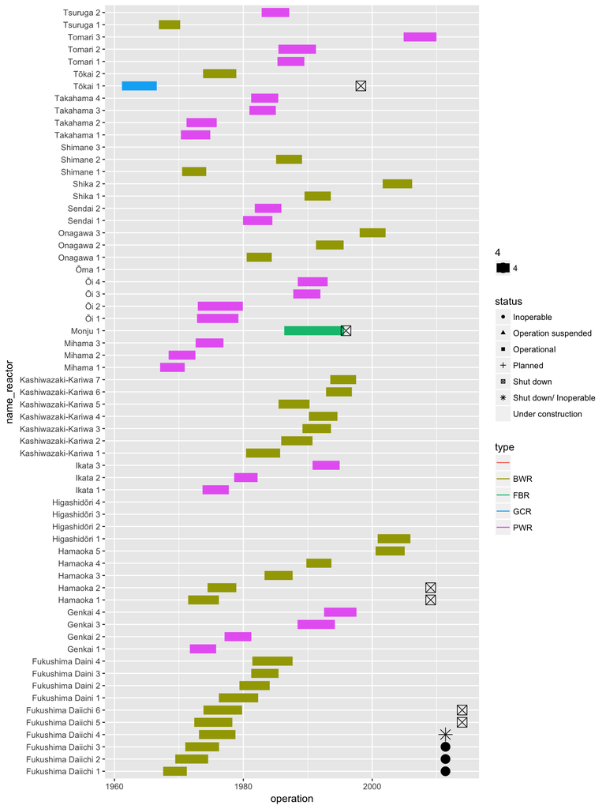

```r
Japan %>%
  mutate(name_reactor = paste(name, reactor)) %>%
  ggplot(aes(y = name_reactor, x = operation, size = 4)) +
  geom_segment(aes(y = name_reactor, yend = name_reactor, x = construction, xend = operation, color = type)) +
  geom_point(aes(y = name_reactor, x = closure, shape = status))
```